# Homework 10

# Preliminaries

- This file should be in `STAT240/homework/hw10` on your local computer.
- Download `superbowl_commercials.csv` to `STAT240/data`.

# Problem 1

The file `superbowl_commercials.csv` contains a list of advertisements for 10 brands aired during Super Bowls from 2000 to 2020. Each advertisement is classified according to several characterisitcs. More information can be found [here](https://github.com/fivethirtyeight/superbowl-ads).

Transform the data as follows:

- Group the rows by brand
- Count the number of ads described as “Funny”
- Count the total number of ads
- Find the proportion of “Funny” ads for each brand
- Save the dataset as an object called `prob1`
- Print the dataset

```r
commercials <- read_csv("../../data/superbowl_commercials.csv")
```

```r
prob1 <- commercials %>%
  group_by(Brand) %>%
  summarize(n_funny = sum(Funny), n_tot = n()) %>%
  mutate(p_funny = n_funny/n_tot)

prob1
```

```
## # A tibble: 10 × 4
##    Brand     n_funny n_tot p_funny
##    <chr>       <int> <int>   <dbl>
##  1 Bud Light      59    62   0.952
##  2 Budweiser      21    43   0.488
##  3 Coca-Cola       8    21   0.381
##  4 Doritos        25    26   0.962
##  5 E-Trade        13    14   0.929
##  6 Hyundai        12    22   0.545
##  7 Kia             8    13   0.615
##  8 NFL             2    11   0.182
##  9 Pepsi          18    25   0.72
## 10 Toyota          6    12   0.5
```

# Problem 2

Starting from `prob1`, count the total number of ads in the dataset, as well as the total number of “Funny” ads. Build and interpret a 99% CI for $p_{funny}$, the overall proportion of funny ads across all of the brands. Use the Agresti-Coull adjustment.

```r
# Total number of ads (number of rows of original data)
n <- sum(prob1$n_tot)

# Number of funny ads
x <- sum(prob1$n_funny)

phat_ac <- (x + 2) / (n + 4)


# Standard error with AC adjustment
se_ac <- sqrt(phat_ac*(1 - phat_ac)/(n+4))

# Critical value
cv <- qnorm(0.995)
```

> Our point estimate for the proportion of funny ads (after applying the AC adjustment) is 0.688. This gives a standard error of about 0.029. Finally, the Z critical value for 99% confidence is $z_{0.005} = 2.576.

```r
# Find upper and lower bounds of interval
c(phat_ac - cv*se_ac, phat_ac + cv*se_ac)
```

```
## [1] 0.6127016 0.7627925
```

> We are 99% confident that the true proportion of funny advertisements is within (0.613, 0.763).

# Problem 3

Repeat the analysis in problem 2, but build a 99% CI fo for $p_{funny}$ with the Wald adjustment. How do the two intervals compare?

> Compared to the interval in 2, we use the same Z critical value, but a different point estimate and standard error. We are not adding any new observations, just using $\hat{p}$ directly in place of $p$.

```r
# Total number of ads (number of rows of original data)
n <- sum(prob1$n_tot)

# Number of funny ads
x <- sum(prob1$n_funny)

phat <- x / n


# Standard error with AC adjustment
se <- sqrt(phat*(1 - phat)/(n+4))

# Find upper and lower bounds of interval
c(phat - cv*se, phat + cv*se)
```

```
## [1] 0.6159173 0.7656088
```

The 99% Wald CI is (0.616, 0.766). The two intervals are very similar, but the AC interval is shifted slightly towards 0.5.

# Problem 4

Perform a hypothesis test to determine whether more than half of superbowl ads are funny. Use hyoptheses
$$H_0: p_{funny} = 0.5 \quad \text{versus}\quad
H_A: p_{funny} > 0.5$$
and $\alpha = 0.01$. Interpret your result in context.

> Under $H_0$, the number of funny ads out of 249 is Binom(249, 0.5). The observed number of funny ads is $x_{obs} = 172$. To calculate a p-value, we need to find the probability of seeing 172 *or more* ads that are funny, under the null assumption.

```r
1 - pbinom(171, 249, 0.5)
```

```
## [1] 8.219346e-10
```

> If one-half of advertisements are funny, the proability of seeing our observed data or something more extreme is very small. Our p-value is much smaller than $\alpha = 0.01$, so we reject $H_0$. We have evidence that more than half of ads are funny.

# Problem 5

State the model and assumptions you used to perform inference on $p_{funny}$ in problems 2-4. State one criticism where reality may differ from the assumptions, potentially leading to misleading conclusions.

> The null distribution in my hypothesis test for $p$ assumes the count of funny ads is binomial with $n = 249$ and some success probability $p$. We use this result to further assume the proportion of funny ads is approximately normal, which is why we built Z confidence intervals.

> These assumptions rely on the BINS assumptions, but I am skeptical about the “S” or same probability assumption. The $n = 249$ counts the ads across 10 different companies, and different companies might be more or less likely to advertise their product with humor.

# Problem 6

Now, focus on $p_{H, funny}$, which is the proportion of Hyundai ads that are funny. Perform a **two-sided** hypothesis test to determine whether or not half of all Hyundai ads are funny. State your hypotheses, test statistic, null distribution, p-value, and conclusion.

> For a two-sided test, the alternative needs to cover both directions. We want to find evidence that the proportion is less than half OR greater than half. We have hypotheses

> $H_0: p_{H, funny} = 0.5 \quad \text{versus} \quad H_A: p_{H, funny} \neq 0.5$.

> According to the summary table, there are 22 total Hyundai ads, giving a null distribution of Binom(22, 0.5). We have an observed test statistic of $x_{obs} = 12$, so we need to assess which outcomes on Binom(22, 0.5) are less likely than 12. We can optionally visualize this as well.

```r
# Probability of 12
dbinom(12, 22, 0.5)
```

```
## [1] 0.1541724
```

```r
# Make a table of probabilities
tibble(
  x = 8:14,
  prob = dbinom(x, 22, 0.5),
  lessThanP57 = prob < dbinom(12, 22, 0.5)
)
```

```
## # A tibble: 7 × 3
##       x   prob lessThanP57
##   <int>  <dbl> <lgl>
## 1     8 0.0762 TRUE
## 2     9 0.119  TRUE
## 3    10 0.154  FALSE
## 4    11 0.168  FALSE
## 5    12 0.154  FALSE
## 6    13 0.119  TRUE
## 7    14 0.0762 TRUE
```

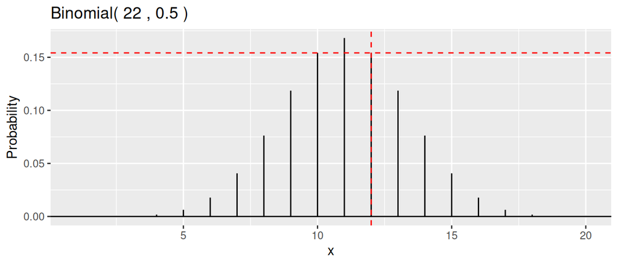

```r
gbinom(22, 0.5, scale = TRUE, col = "black") +
  geom_vline(xintercept = 12, color = "red", lty = 2) +
  geom_hline(yintercept = dbinom(12, 22, 0.5), color = "red", lty = 2)
```

```r
# Two-sided p-value
pbinom(10, 22, 0.5) + pbinom(11, 22, 0.5, lower.tail = F)
```

```
## [1] 0.8318119
```

> We get a very large p-value of 0.83, which suggests weak evidence against the null. We fail to find evidence that $p_{H, funny}$ is different from 0.5.

# Problem 7

Consider comparing the proportion of Hyundai ads that are funny to the proportion of Budweiser ads that are funny. Build a 95% confidence interval on the difference in proportions and use the Agresti-Coffe adjustment. Interpret your results in context.

```r
# Counts of totals and funny ads
n_h <- 22
x_h <- 12
n_b <- 43
x_b <- 21

# Make AC adjustment to both groups
phat_h_ac <- (x_h + 1) / (n_h + 2)
phat_b_ac <- (x_b + 1) / (n_b + 2)

pt_est <- phat_h_ac - phat_b_ac

# Standard error with AC adjustment
se_ac <- sqrt(phat_h_ac*(1 - phat_h_ac)/(n_h + 2) + phat_b_ac*(1 - phat_b_ac)/(n_b + 2))

# Critical value
cv <- qnorm(0.975)
```

> The point estimate is the observed difference in proportions, after adding 1 success and 1 failure to each group. This is about 0.053. The standard error with the AC adjustment is 0.126. Finally, the Z critical value for 95% confidence is $z_{0.025} = 1.96$.

```r
# Find upper and lower bounds of interval
c(pt_est - cv*se_ac, pt_est + cv*se_ac)
```

```
## [1] -0.1943421  0.2998976
```

> We are 95% confident that the difference in the proportion of funny ads for Hyndai and Budweiser is within (-0.194, 0.3).

# Problem 8

Perform a hypothesis test to determine whether a *different* proportion of Hyndai ads than Budweiser ads are funny. Write appropriate two-sided hypotheses and draw a conclusion with $\alpha = 0.05$.

> Our two-sided hypotheses are

> $$H_0: p_{H, funny} = p_{B, funny} \quad
> \text{versus} \quad H_A: p_{H, funny} \neq p_{B, funny}$$
> or
> $$H_0: p_{H, funny} - p_{B, funny} = 0 \quad
> \text{versus} \quad H_A: p_{H, funny} - p_{B, funny} \neq 0$$

> Our point estimate is the difference in proportions *without* the AC adjustment. We also need to calculate a standard error with a pooled proportion of funny ads, which we estimate with
> $$\frac{x_h + x_b}{n_h + n_b}$$

```r
# Counts of totals and funny ads
n_h <- 22
x_h <- 12
n_b <- 43
x_b <- 21

# Unadjusted point estimate of difference
p_diff <- (x_h / n_h) - (x_b / n_b)

# Common proportion of success
p_hat <- (x_h + x_b) / (n_h + n_b)

# Standard error with common proportion + group sample sizes
se <- sqrt(p_hat*(1 - p_hat)*(1/n_h + 1/n_b))

# Test statistic
z_obs <- p_diff / se
```

> We get an observed test statistic of $\frac{\hat{p}_{H, funny} - \hat{p}_{B, funny}}{\hat{se}} = 0.436$. Under $H_0$, this value was drawn from a standard normal curve. For a two-sided p-value, we need to account for all of the possibilities more extreme than 0.436 in *both directions*. This is $P(Z < -0.436) + P(Z > 0.436)$.

```r
2*pnorm(0.436, lower.tail = F)
```

```
## [1] 0.6628367
```

> We get a large p-value of 0.663 and fail to reject $H_0$. There is no evidence in the difference of the proportion of funny ads ran by Hyundai and Budweiser.